# correlaid_text_analysis

Xiang XU, Jing(Mira) Tang, Ningze(Summer) ZU, Jianhao(Miller) Yan

November 3, 2018

## look at single word frequency and visualize

### first at doc1

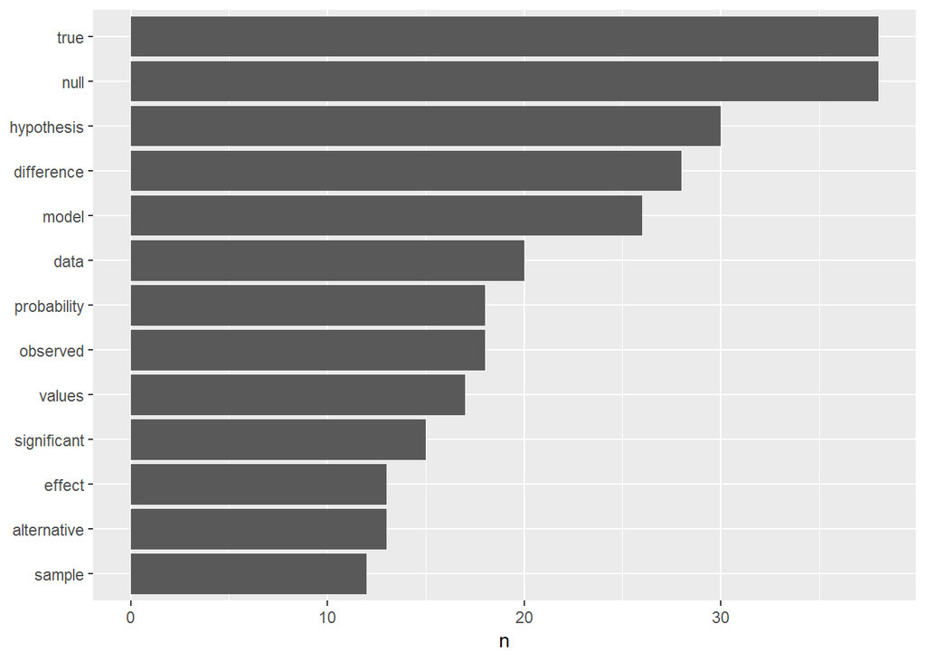

### plotting and comparing the three articles

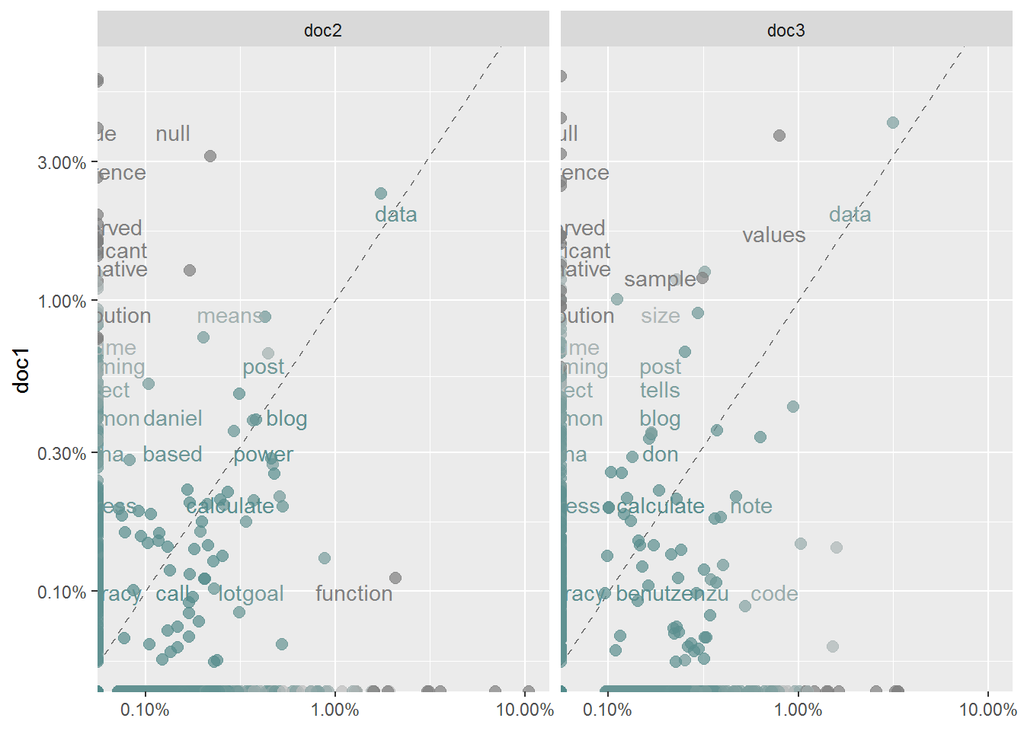

```
##
##  Pearson's product-moment correlation
##
## data:  proportion and doc1
## t = -0.90635, df = 800, p-value = 0.365
## alternative hypothesis: true correlation is not equal to 0
## 95 percent confidence interval:
##  -0.10103135  0.03728257
## sample estimates:
##         cor
## -0.03202772
```

```
##
##  Pearson's product-moment correlation
##
## data:  proportion and doc1
## t = -1.3419, df = 800, p-value = 0.18
## alternative hypothesis: true correlation is not equal to 0
## 95 percent confidence interval:
##  -0.11623528  0.02191054
## sample estimates:
##         cor
## -0.04738898
```

*As we saw in the plots, the word frequencies have little frequencies in three articles.*

# Sentiment analysis

### bing sentiment analysis

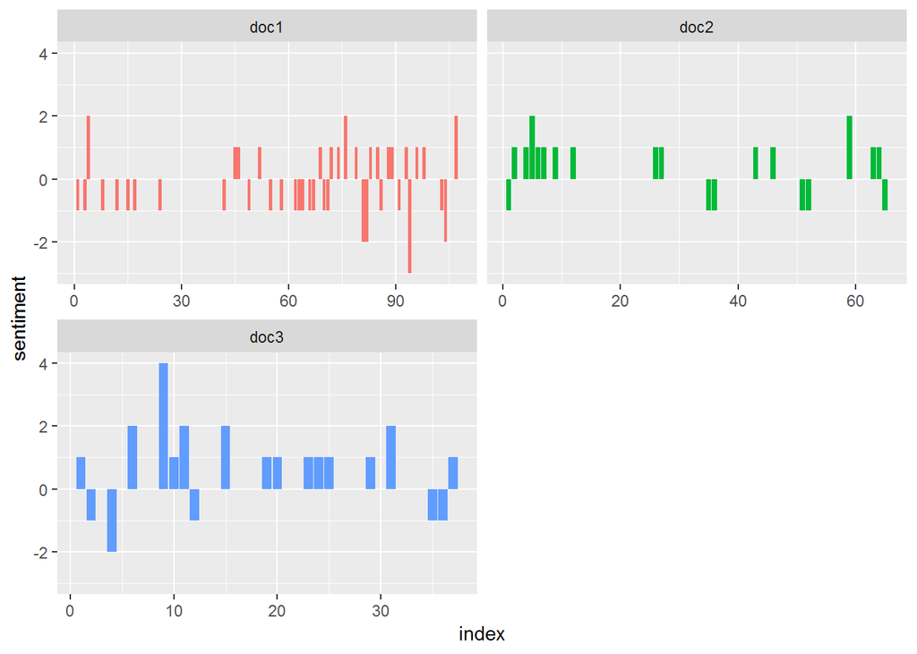

## Comparing the three sentiment dictionaries

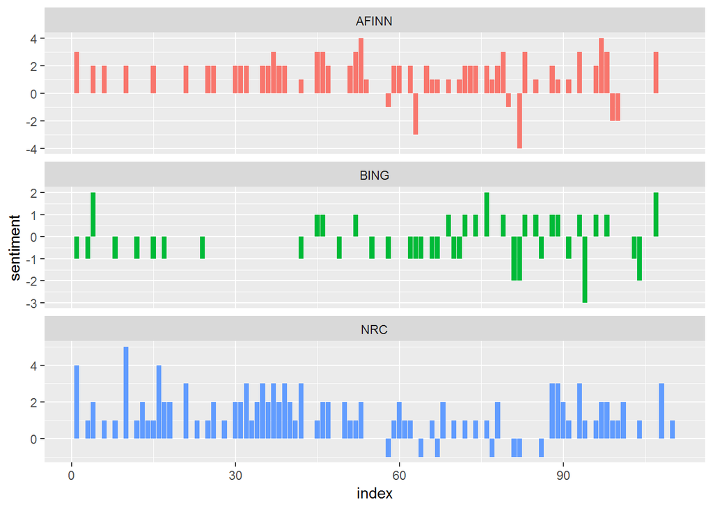

## Most common sentiment words

```
## # A tibble: 79 x 3
##    word           sentiment     n
##    <chr>          <chr>     <int>
##  1 significant    positive     15
##  2 correct        positive      7
##  3 misconceptions negative      7
##  4 fall           negative      6
##  5 error          negative      4
##  6 false          negative      4
##  7 happy          positive      4
##  8 plot           negative      4
##  9 confusing      negative      3
## 10 deviation      negative      3
## # ... with 69 more rows
```

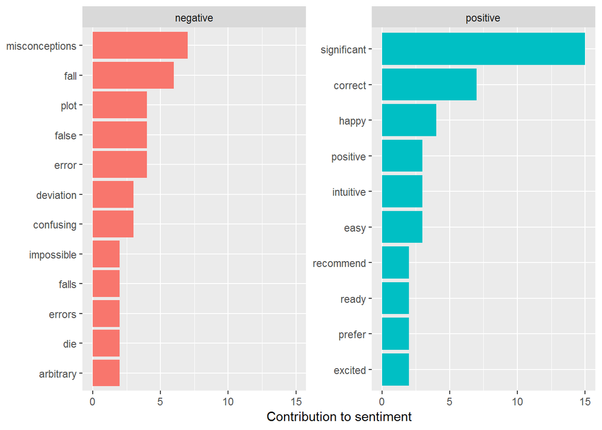

## Wordclouds

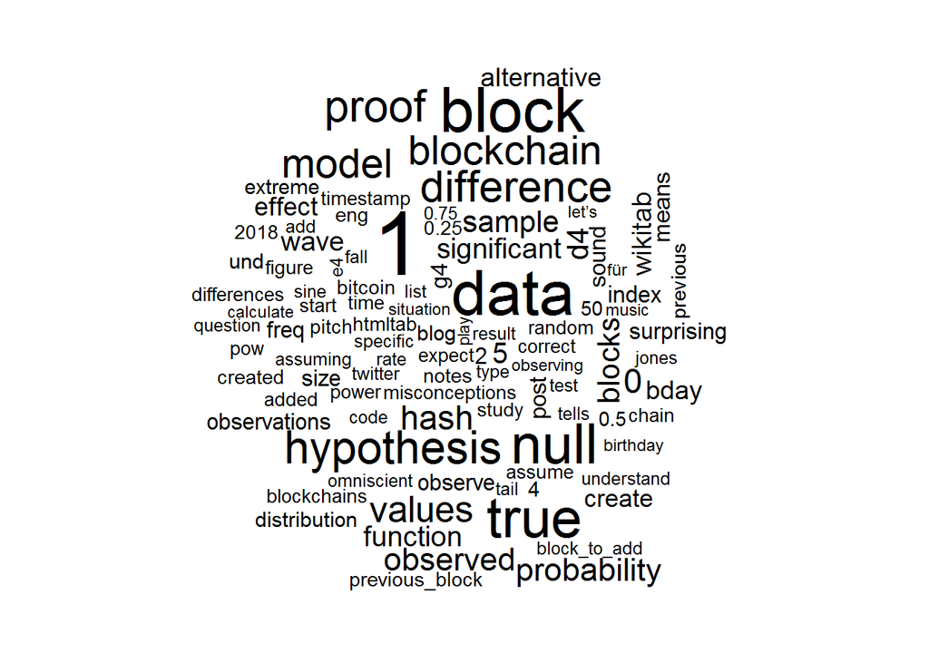

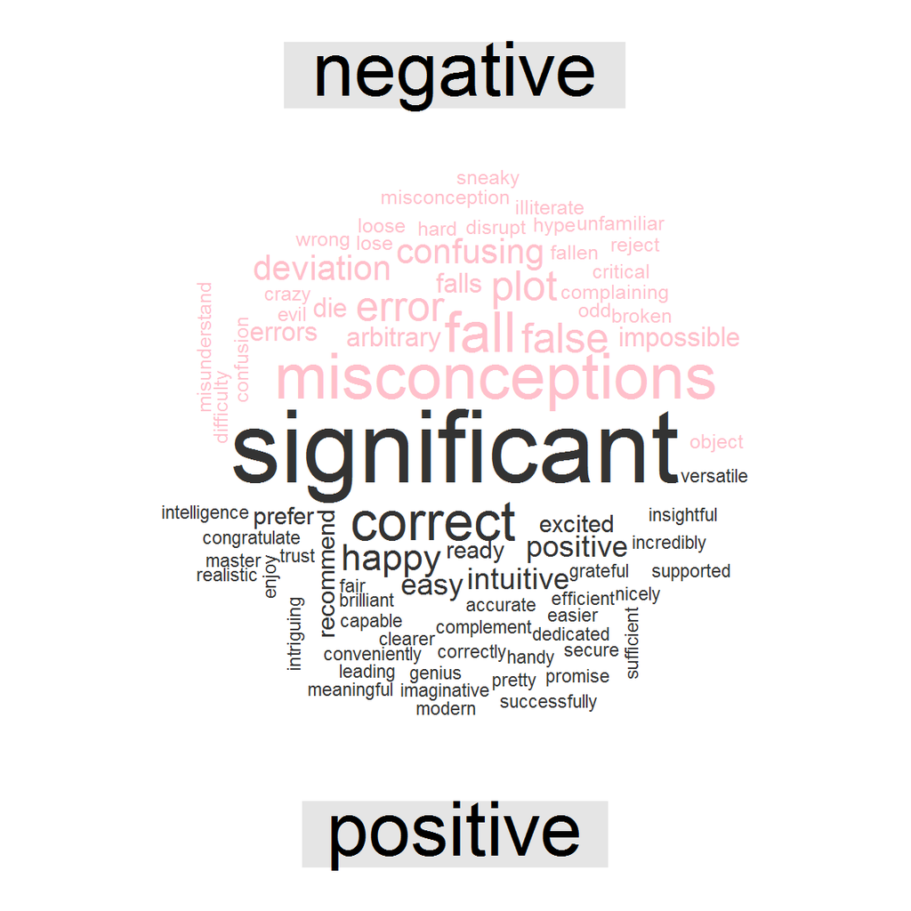

# Chapter 3 tf-idf

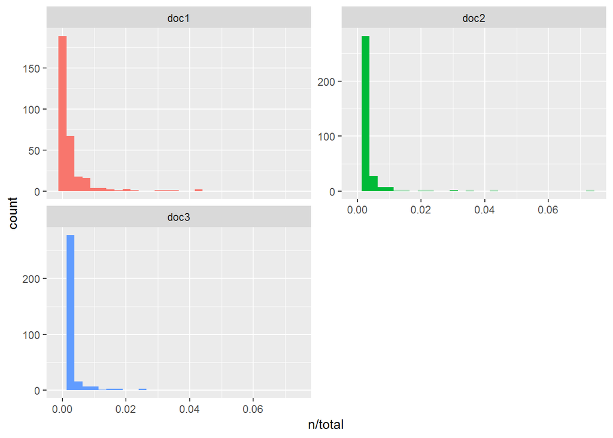

```
## (Intercept) log10(rank)
##  -1.0057750  -0.8284333
```

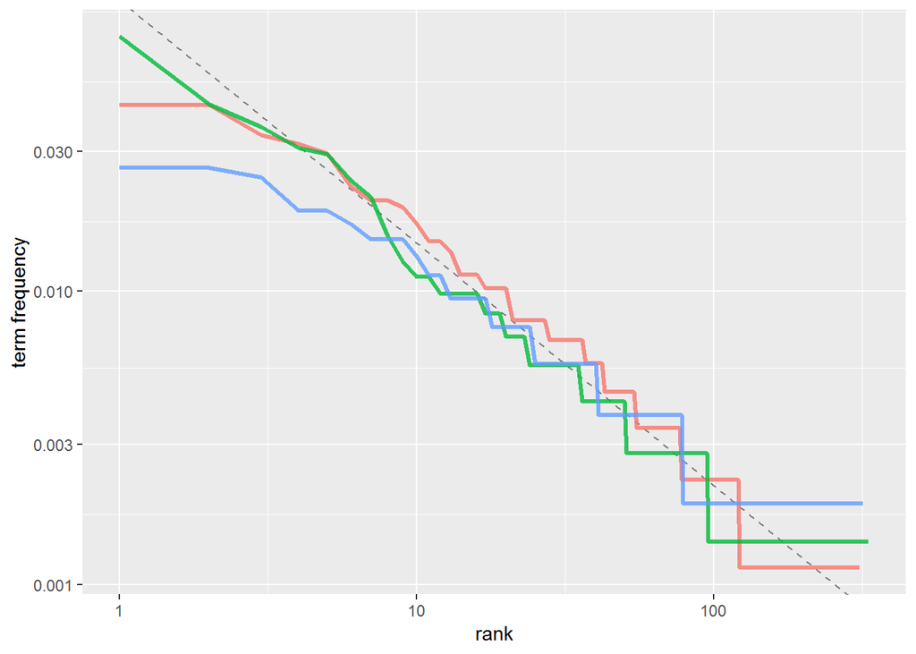

### tf-idf function

```
## # A tibble: 960 x 6
##    article word           n     tf   idf tf_idf
##    <chr>   <chr>      <int>  <dbl> <dbl>  <dbl>
##  1 doc2    block         53 0.0742  1.10 0.0815
##  2 doc2    proof         31 0.0434  1.10 0.0477
##  3 doc1    true          38 0.0432  1.10 0.0475
##  4 doc2    blockchain    26 0.0364  1.10 0.0400
##  5 doc1    hypothesis    30 0.0341  1.10 0.0375
##  6 doc1    difference    28 0.0319  1.10 0.0350
##  7 doc2    hash          22 0.0308  1.10 0.0339
##  8 doc1    model         26 0.0296  1.10 0.0325
##  9 doc2    previous      21 0.0294  1.10 0.0323
## 10 doc3    wave          14 0.0264  1.10 0.0290
## # ... with 950 more rows
```

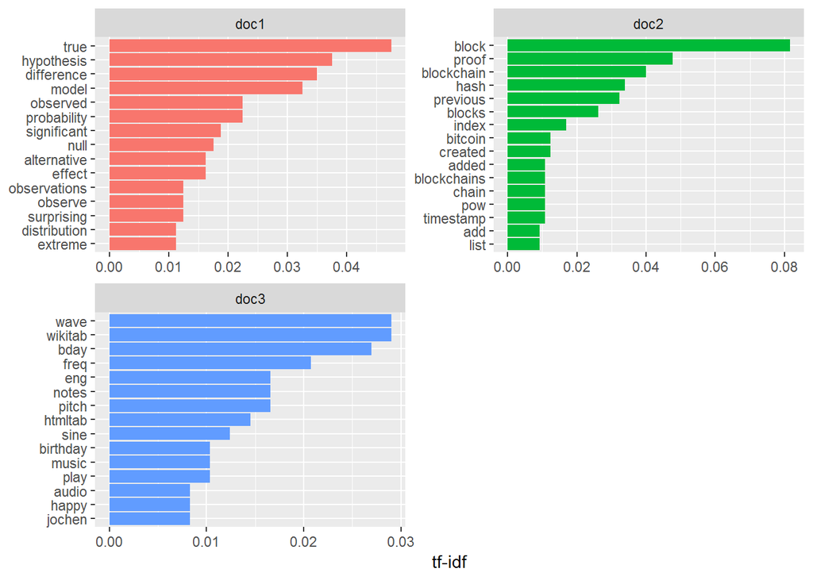

# Chapter 4 n-grams and correlations

We use `unnest_tokens` function to tokenize the articles into consecutive sequences of words, called n-grams. Here we focus on bigrams, aka two consecutive words.

As one might expect, a lot of the most common bigrams are pairs of common (uninteresting) words, such as of the and to be: what we call “stop-words” . This is a useful time to use tidyr’s `separate()` and `unite()`, which splits a column into multiple based on a delimiter and reunite them. In this process we can remove cases where either is a stop-word.

Also, we clean the bigrams by `str_extract()` and `filter()` function to remove cases where either is NA, space or non-letter word.

Then we look at tf_idf of bigrams and visualize them.

```
## # A tibble: 10 x 6
##    article bigram                     n     tf   idf tf_idf
##    <chr>   <chr>                  <int>  <dbl> <dbl>  <dbl>
##  1 doc1    null hypothesis           21 0.0843  1.10 0.0927
##  2 doc1    null model                15 0.0602  1.10 0.0662
##  3 doc2    previous block            13 0.0478  1.10 0.0525
##  4 doc1    alternative model          7 0.0281  1.10 0.0309
##  5 doc2    previous hash              7 0.0257  1.10 0.0283
##  6 doc1    omniscient jones           6 0.0241  1.10 0.0265
##  7 doc1    sample size                6 0.0241  1.10 0.0265
##  8 doc1    significant result         6 0.0241  1.10 0.0265
##  9 doc3    wikitab eng                6 0.0231  1.10 0.0254
## 10 doc1    alternative hypothesis     5 0.0201  1.10 0.0221
```

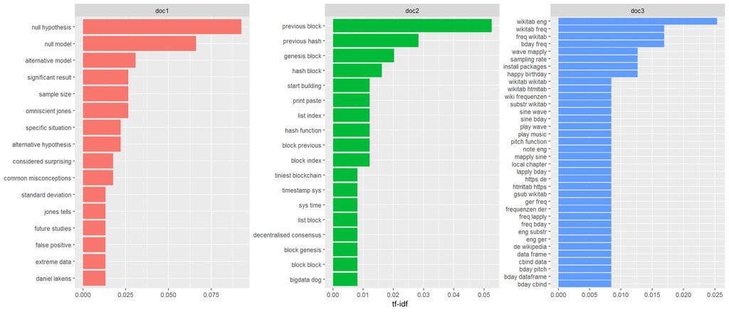

There are advantages and disadvantages to examining the tf-idf of bigrams rather than individual words. Pairs of consecutive words might capture structure that isn’t present when one is just counting single words, and may provide context that makes tokens more understandable . However, the per-bigram counts are also sparser: a typical two-word pair is rarer than either of its component words. Thus, bigrams can be more useful when we have a larger text dataset.

- Using bigrams to provide context in sentiment analysis

```
## # A tibble: 0 x 4
## # ... with 4 variables: word1 <chr>, word2 <chr>, score <int>, nn <int>
```

For these are three academic articles and there are not many bigrams with negative terms. So we can skip this part.

- Visualizing a network of bigrams with ggraph